The goal of your project is to predict the manner in which they did the exercise. This is the “classe” variable in the training set. You may use any of the other variables to predict with. You should create a report describing how you built your model, how you used cross validation, what you think the expected out of sample error is, and why you made the choices you did. You will also use your prediction model to predict 20 different test cases. Data The training data for this project are available here: https://d396qusza40orc.cloudfront.net/predmachlearn/pml-training.csv The test data are available here: https://d396qusza40orc.cloudfront.net/predmachlearn/pml-testing.csv

loading data

```r
setwd("C:\\Users\\suman\\Desktop\\datasciencecoursera\\mclearning")
training<-read.table("pml-training.csv",sep=',',header=TRUE)
testing<-read.table("pml-testing.csv",sep=',',header=TRUE)
```

cleanning data remode na where na is more than 19621 and remove first 6 columns

```r
training_clean<-training[,7:160]
training_clean<-training_clean[lapply(training_clean,function(x) sum(is.na(x))/length(x))<.1]


#is_data<-apply(!is.na(training_clean),2,sum)>19621
#training_clean<-training[,is_data]
#ncol(training_clean)
```

split training data in 2 part

```r
library(caret)
set.seed(3141592)
intrain<-createDataPartition(y=training_clean$classe,p=.6,list=FALSE)
train1<-training_clean[intrain,]
train2<-training_clean[-intrain,]
dim(train1)
```

```
## [1] 11776    87
```

```r
dim(train2)
```

```
## [1] 7846   87
```

remove almost 0 variance records

```r
nzv_cols <- nearZeroVar(train1)
if(length(nzv_cols)>0){
  train1<-train1[,-nzv_cols]
  train2<-train2[,-nzv_cols]
}
dim(train1)
```

```
## [1] 11776    54
```

```r
dim(train2)
```

```
## [1] 7846   54
```

apply model as the data is now clean

```r
library(randomForest)
```

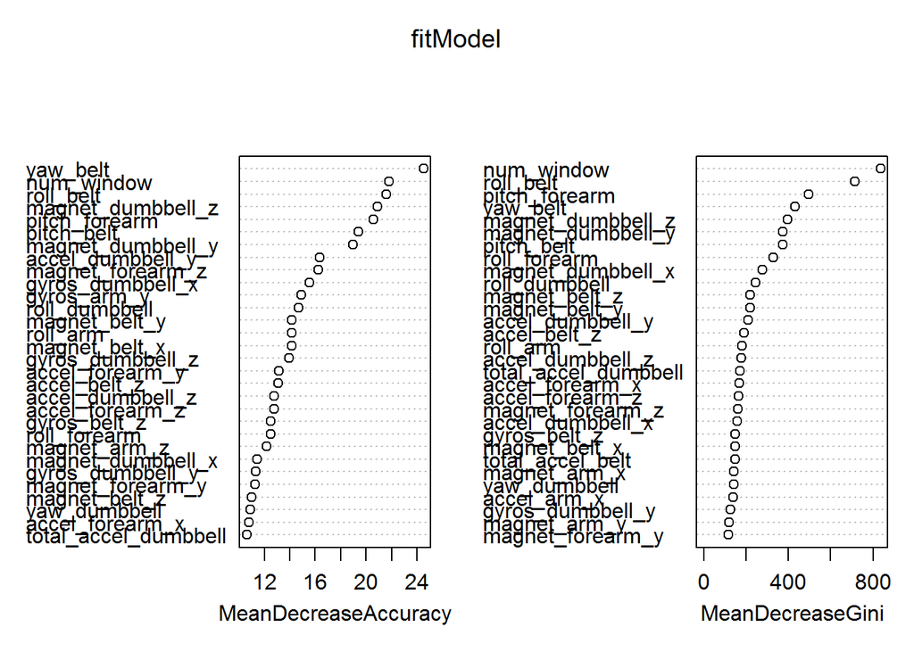

```r
fitModel <- randomForest(classe~., data=train1, importance=TRUE, ntree=100)
varImpPlot(fitModel)
```

using the accuracy and gini graph we select top 10 variable to consider. if the accuracy is acceptable limiting varible is good idea.Our 10 covariates are: yaw_belt, roll_belt, num_window, pitch_belt, magnet_dumbbell_y, magnet_dumbbell_z, pitch_forearm, accel_dumbbell_y, roll_arm, and roll_forearm.Let’s analyze the correlations between these 10 variables. The following code calculates the correlation matrix. replaces the 1s in the diagonal with 0s, and outputs which variables have an absolute value correlation above 75%:

```r
correl = cor(train1[,c("yaw_belt","roll_belt","num_window","pitch_belt","magnet_dumbbell_z","magnet_dumbbell_y","pitch_forearm","accel_dumbbell_y","roll_arm","roll_forearm")])
diag(correl) <- 0
which(abs(correl)>0.75, arr.ind=TRUE)
```

```
##           row col
## roll_belt   2   1
## yaw_belt    1   2
```

```r
cor(train1$roll_belt, train1$yaw_belt)
```

```
## [1] 0.8152349
```

relation between below 2 variables can be seen by #qplot(roll_belt, magnet_dumbbell_y, colour=classe, data=train1)

try decision tree

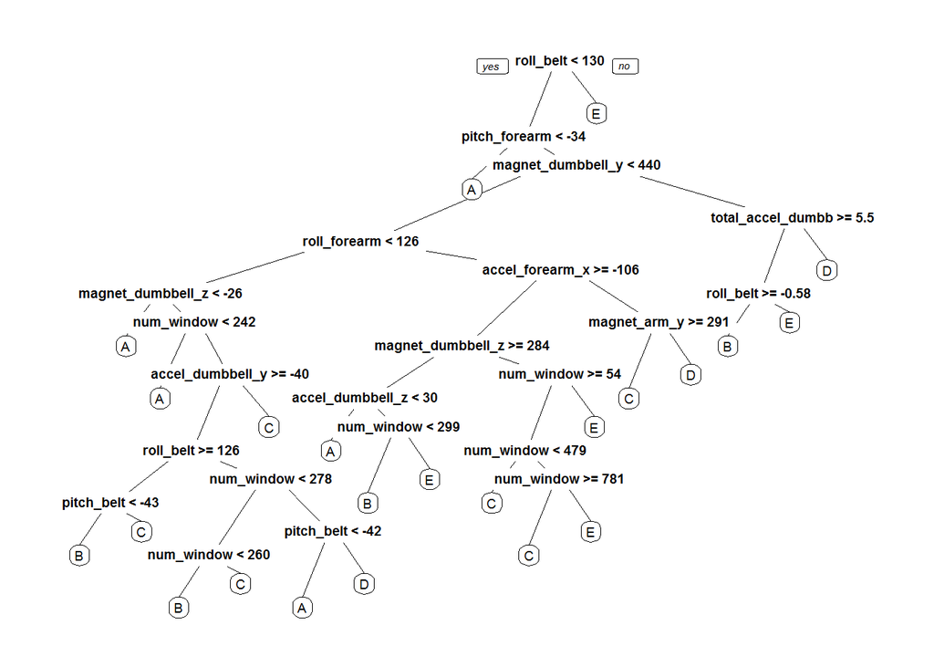

```r
library(rpart.plot)
fitModel <- rpart(classe~., data=train1, method="class")
prp(fitModel)
```

```r
fitModel <- randomForest(classe~roll_belt+num_window+pitch_belt+magnet_dumbbell_y+magnet_dumbbell_z+pitch_forearm+accel_dumbbell_y+roll_arm+roll_forearm,
                  data=train1,
                  method="rf",
                  trControl=trainControl(method="cv",number=2),
                  prox=TRUE,
                  verbose=TRUE,
                  allowParallel=TRUE)
```

save the model and use later

```r
saveRDS(fitModel, "modelRF.Rds")
fitModel <- readRDS("modelRF.Rds")
```

find accuracy

```r
library(e1071)
predictions <- predict(fitModel, newdata=train2)
confusionMat <- confusionMatrix(predictions, train2$classe)
confusionMat
```

```
## Confusion Matrix and Statistics
##
##           Reference
## Prediction    A    B    C    D    E
##          A 2231    0    0    0    0
##          B    1 1516    0    0    1
##          C    0    1 1368    6    1
##          D    0    1    0 1280    3
##          E    0    0    0    0 1437
##
## Overall Statistics
##
##                Accuracy : 0.9982
##                  95% CI : (0.997, 0.999)
##     No Information Rate : 0.2845
##     P-Value [Acc > NIR] : < 2.2e-16
##
##                   Kappa : 0.9977
##  Mcnemar's Test P-Value : NA
##
## Statistics by Class:
##
##                      Class: A Class: B Class: C Class: D Class: E
## Sensitivity            0.9996   0.9987   1.0000   0.9953   0.9965
## Specificity            1.0000   0.9997   0.9988   0.9994   1.0000
## Pos Pred Value         1.0000   0.9987   0.9942   0.9969   1.0000
## Neg Pred Value         0.9998   0.9997   1.0000   0.9991   0.9992
## Prevalence             0.2845   0.1935   0.1744   0.1639   0.1838
## Detection Rate         0.2843   0.1932   0.1744   0.1631   0.1832
## Detection Prevalence   0.2843   0.1935   0.1754   0.1637   0.1832
## Balanced Accuracy      0.9998   0.9992   0.9994   0.9974   0.9983
```

```r
predictions <- predict(fitModel, newdata=testing)
testing$classe <- predictions
submit <- data.frame(problem_id = testing$problem_id, classe = predictions)
write.csv(submit, file = "coursera-submission.csv", row.names = FALSE)
```